# Майнор "Интеллектуальный анализ данных"

# Курс "Введение в анализ данных"

# Лабораторная работа №2. Кластерный анализ.

# Часть 1

В данном задании вам необходимо **самостоятельно** реализовать один из алгоритмов кластеризации.  
По аналогии с классами в scikit-learn, нужно реализовать класс, наследуемый от [Base Estimator](https://scikit-learn.org/stable/modules/generated/sklearn.base.BaseEstimator.html).  
Подробнее про реализацию своих моделей в scikit-learn: [here](https://scikit-learn.org/stable/developers/develop.html#rolling-your-own-estimator).  
В классе помимо `__init__()` нужно реализовать два метода:

- `fit()` - метод, выполняющий кластеризацию данных.
- `predict()` - метод, определяющий для нового объекта, к какому из кластеров он относится.

Для удобства можно создавать дополнительные методы класса, которые будут вызываться в `fit()` или `predict()`.  
Функции для вычисления расстояний *между объектами* самим реализовывать не нужно, используйте реализации из `scipy`.

```python
import numpy as np
import pandas as pd
from sklearn.datasets import load_iris
import matplotlib.pyplot as plt
import seaborn as sns

from sklearn.base import BaseEstimator, ClusterMixin
```

### Вариант №2

Алгоритм Dbscan.

Параметры:

- **eps:** радиус окрестности $\varepsilon$;
- **min_samples:** минимальное число объектов в окрестности $\varepsilon$ для основных точек;
- **metric:** функция расстояния между объектами. Должны поддерживаться метрики из `scipy.spatial.distance`, самописные функции (callable) и предрассчитанная матрица расстояний.
- **metric_params:** параметры функции расстояния, если такие есть.

Атрибуты:

- **core_sample_coords_:** - векторы основных точек;
- **labels_:** метки кластеров для каждого объекта.

Метод `predict()`: Для нового объекта вычисляется число основных точек из каждого кластера, попавших в окрестность $\varepsilon$. Объект определяется в кластер с наибольшим числом таких точек.  
**Note:** Метод `predict()` не выполняется в случае, когда **metric** - это матрица расстояний.

```python
from sklearn.base import BaseEstimator, ClusterMixin

class My_Clust(BaseEstimator, ClusterMixin):
    """
    My implementation of clustering algorithm
    """

    def __init__(self, **kwargs):
        """
        Please add necessary algoritm parameters to class constructor.
        """
        # Your code here


    def fit(self, X):
        """
        Use data matrix X to compute model parameters
        """
        # Your code here

    def predict(self, X):
        """
        Using computed model parameters predict cluster
        for all objects from matrix X
        """
        # Your code here

        return new_labels
```

### Тестирование

Вашу реализацию необходимо сравнить с питоновской реализацией алгоритма из `sklearn` или `scipy`. Результаты кластеризации должны совпадать.  
Также необходимо сравнить скорость работы вашей реализации и питоновской (это нормально, если ваша реализация будет медленнее).  
Сравнение необходимо выполнить на наборе данных iris.

```python
iris = load_iris()
X = iris.data # использовать для кластеризации
y = iris.target # истинные метки цветков
```

```python
X = pd.DataFrame(X, columns=iris.feature_names)
X['class'] = [iris.target_names[i] for i in y]
```

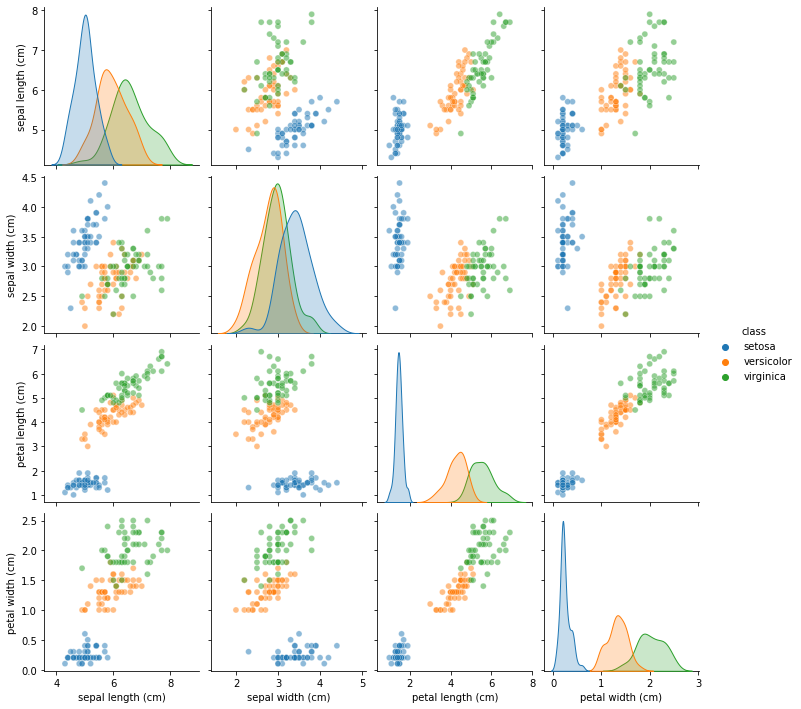

```python
sns.pairplot(X, hue='class', plot_kws={'alpha':0.5}, vars=iris.feature_names)
plt.show()
```

### Бонусное

Дополнительно вы можете поработать над эффективностью алгоритма по скорости и памяти, добавить поддержку многопоточности, или расширить базовый функционал.

### Распределение по вариантам

```python
pd.set_option('display.max_rows', 50)
```

```python
Vars = pd.read_csv('Vars.txt', sep='\t')
```

#### Вариант №1

```python
Vars[Vars.iloc[:,2] == 1]
```

|  | ФИО | Группа | Вариант № |
| --- | --- | --- | --- |
| 0 | Бакурский Андрей Сергеевич | 1 ИАД | 1 |
| 2 | Бекина Светлана Сергеевна | 1 ИАД | 1 |
| 3 | Бекусов Михаил Александрович | 1 ИАД | 1 |
| 9 | Конина Татьяна Дмитриевна | 1 ИАД | 1 |
| 11 | Лукичева Полина Александровна | 1 ИАД | 1 |
| 12 | Моничева Арина Александровна | 1 ИАД | 1 |
| 22 | Трухин Егор Сергеевич | 1 ИАД | 1 |
| 23 | Шарунов Евгений Александрович | 1 ИАД | 1 |
| 24 | Шатилов Виктор Алексеевич | 1 ИАД | 1 |
| 27 | Астахова Елизавета Евгеньевна | 2 ИАД | 1 |
| 29 | Баранов Денис Алексеевич | 2 ИАД | 1 |
| 30 | Баховаддинов Искандар Худайбердиевич | 2 ИАД | 1 |
| 34 | Казюлина Марина Сергеевна | 2 ИАД | 1 |
| 35 | Карабасова Юлия Алексеевна | 2 ИАД | 1 |
| 38 | Меркулова Екатерина Владимировна | 2 ИАД | 1 |
| 40 | Сазанов Илья Денисович | 2 ИАД | 1 |
| 45 | Тормашова Валерия Сергеевна | 2 ИАД | 1 |
| 47 | Федоров Макар Андреевич | 2 ИАД | 1 |
| 50 | Шешменева Кристина Сергеевна | 2 ИАД | 1 |
| 53 | Артюх Майя Сергеевна | 3 ИАД | 1 |
| 59 | Лашина Надежда Андреевна | 3 ИАД | 1 |
| 61 | Рябинина Полина Викторовна | 3 ИАД | 1 |
| 63 | Харинский Дмитрий Сергеевич | 3 ИАД | 1 |

#### Вариант №2

```python
Vars[Vars.iloc[:,2] == 2]
```

|  | ФИО | Группа | Вариант № |
| --- | --- | --- | --- |
| 1 | Балаян Роман Каренович | 1 ИАД | 2 |
| 5 | Даняев Артем Андреевич | 1 ИАД | 2 |
| 7 | Ешманов Павел Андреевич | 1 ИАД | 2 |
| 10 | Костин Андрей Олегович | 1 ИАД | 2 |
| 15 | Ожиганова Полина Максимовна | 1 ИАД | 2 |
| 17 | Сапожников Андрей Михайлович | 1 ИАД | 2 |
| 18 | Семаев Никита Юрьевич | 1 ИАД | 2 |
| 21 | Суворов Артём Андреевич | 1 ИАД | 2 |
| 25 | Южаков Максим Вячеславович | 1 ИАД | 2 |
| 28 | Бабий Александр Сергеевич | 2 ИАД | 2 |
| 32 | Гаранина Мария Евгеньевна | 2 ИАД | 2 |
| 33 | Гаращенкова Анна Александровна | 2 ИАД | 2 |
| 36 | Корякин Владислав Андреевич | 2 ИАД | 2 |
| 39 | Мушка Никита Андреевич | 2 ИАД | 2 |
| 42 | Соколова Анна Ильинична | 2 ИАД | 2 |
| 43 | Солдаткин Константин Алексеевич | 2 ИАД | 2 |
| 48 | Харханова Екатерина Михайловна | 2 ИАД | 2 |
| 51 | Шувар Алена Олеговна | 2 ИАД | 2 |
| 55 | Дудин Григорий Алексеевич | 3 ИАД | 2 |
| 56 | Егоров Николай Михайлович | 3 ИАД | 2 |
| 58 | Кучеренко Анна Васильевна | 3 ИАД | 2 |
| 60 | Матвеева Дарья Игоревна | 3 ИАД | 2 |
| 64 | Частова Екатерина Робертовна | 3 ИАД | 2 |
| 67 | Шемет Савелий Кириллович | 3 ИАД | 2 |

#### Вариант №3

```python
Vars[Vars.iloc[:,2] == 3]
```

|  | ФИО | Группа | Вариант № |
| --- | --- | --- | --- |
| 4 | Боряев Сергей Сергеевич | 1 ИАД | 3 |
| 6 | Дыряев Даниил Александрович | 1 ИАД | 3 |
| 8 | Игумнова Наталья Дмитриевна | 1 ИАД | 3 |
| 13 | Мурзинов Михаил Денисович | 1 ИАД | 3 |
| 14 | Николаева Олеся Игоревна | 1 ИАД | 3 |
| 16 | Османов Ислам Рамилевич | 1 ИАД | 3 |
| 19 | Смирнов Григорий Андреевич | 1 ИАД | 3 |
| 20 | Стифеев Никита Владимирович | 1 ИАД | 3 |
| 26 | Арбузова Екатерина Михайловна | 2 ИАД | 3 |
| 31 | Варгин Дмитрий Александрович | 2 ИАД | 3 |
| 37 | Левин Глеб Сергеевич | 2 ИАД | 3 |
| 41 | Смирнов Дмитрий Викторович | 2 ИАД | 3 |
| 44 | Терентьева Анастасия Олеговна | 2 ИАД | 3 |
| 46 | Точкова Арина Андреевна | 2 ИАД | 3 |
| 49 | Шарапов Максим Сергеевич | 2 ИАД | 3 |
| 52 | Юдакова Олеся Валерьевна | 2 ИАД | 3 |
| 54 | Басыров Андрей Дмитриевич | 3 ИАД | 3 |
| 57 | Закареишвили Гиоргий Годердзиевич | 3 ИАД | 3 |
| 62 | Семенова Елена Андреевна | 3 ИАД | 3 |
| 65 | Чернов Роман Александрович | 3 ИАД | 3 |
| 66 | Шауклис Александр Николаевич | 3 ИАД | 3 |

# Часть 2

В данном задании вам предлагается проанализировать набор данных по различным городам США. Каждый город характеризуется следующими признаками:

```python
pd.set_option('display.max_colwidth', None)
```

```python
data_desc = pd.read_csv('Data_Description.txt', sep=':')
data_desc
```

|  | Attribute | Description |
| --- | --- | --- |
| 0 | Place | City, state (postal code) |
| 1 | Climate & Terrain | Very hot and very cold months, seasonal temperature variation, heating- and cooling-degree days, freezing days, zero-degree days, ninety-degree days. |
| 2 | Housing | Utility bills, property taxes, mortgage payments. |
| 3 | Health Care & Environment | Per capita physicians, teaching hospitals, medical schools, cardiac rehabilitation centers, comprehensive cancer treatment centers, hospices, insurance/hospitalization costs index, flouridation of dri… |
| 4 | Crime | Violent crime rate, property crime rate. |
| 5 | Transportation | Daily commute, public transportation, Interstate highways, air service, passenger rail service. |
| 6 | Education | Pupil/teacher ratio in the public K-12 system, effort index in K-12, accademic options in higher education. |
| 7 | The Arts | Museums, fine arts and public radio stations, public television stations, universities offering a degree or degrees in the arts, symphony orchestras, theatres, opera companies, dance companies, public… |
| 8 | Recreation | Good restaurants, public golf courses, certified lanes for tenpin bowling, movie theatres, zoos, aquariums, family theme parks, sanctioned automobile race tracks, pari-mutuel betting attractions, majo… |
| 9 | Economics | Average household income adjusted for taxes and living costs, income growth, job growth. |
| 10 | Longitude | Longitude |
| 11 | Latitude | Latitude |
| 12 | Population | Population |

### Notes:

- Для всех признаков, кроме трех, чем выше значение - тем лучше. Для признаков `Housing` и `Crime` - наоборот.
- Признак `Population`- статистический признак, не имеющий интерпретации как “лучше-хуже”.
- Признак `Place` - уникальный идентификатор объекта (города), он не должен использоваться при кластеризации.
- Также в данных присутствуют географические координаты городов - `Longitude` и `Latitude`. Их также не следует использовать при кластеризации данных.

```python
data = pd.read_csv('Data.txt', sep=' ')
data
```

|  | Place | Climate | HousingCost | HlthCare | Crime | Transp | Educ | Arts | Recreat | Econ | Long | Lat | Pop |
| --- | --- | --- | --- | --- | --- | --- | --- | --- | --- | --- | --- | --- | --- |
| 0 | Abilene,TX | 521 | 6200 | 237 | 923 | 4031 | 2757 | 996 | 1405 | 7633 | -99.6890 | 32.5590 | 110932 |
| 1 | Akron,OH | 575 | 8138 | 1656 | 886 | 4883 | 2438 | 5564 | 2632 | 4350 | -81.5180 | 41.0850 | 660328 |
| 2 | Albany,GA | 468 | 7339 | 618 | 970 | 2531 | 2560 | 237 | 859 | 5250 | -84.1580 | 31.5750 | 112402 |
| 3 | Albany-Schenectady-Troy,NY | 476 | 7908 | 1431 | 610 | 6883 | 3399 | 4655 | 1617 | 5864 | -73.7983 | 42.7327 | 835880 |
| 4 | Albuquerque,NM | 659 | 8393 | 1853 | 1483 | 6558 | 3026 | 4496 | 2612 | 5727 | -106.6500 | 35.0830 | 419700 |
| ... | ... | ... | ... | ... | ... | ... | ... | ... | ... | ... | ... | ... | ... |
| 324 | Worcester,MA | 562 | 8715 | 1805 | 680 | 3643 | 3299 | 1784 | 910 | 5040 | -71.7950 | 42.2720 | 402918 |
| 325 | Yakima,WA | 535 | 6440 | 317 | 1106 | 3731 | 2491 | 996 | 2140 | 4986 | -120.5130 | 46.5950 | 172508 |
| 326 | York,PA | 540 | 8371 | 713 | 440 | 2267 | 2903 | 1022 | 842 | 4946 | -76.7280 | 39.9600 | 381255 |
| 327 | Youngstown-Warren,OH | 570 | 7021 | 1097 | 938 | 3374 | 2920 | 2797 | 1327 | 3894 | -80.7290 | 41.1700 | 531350 |
| 328 | Yuba-City,CA | 608 | 7875 | 212 | 1179 | 2768 | 2387 | 122 | 918 | 4694 | -121.6220 | 39.1280 | 101979 |

329 rows × 13 columns

## Задания:

1. Выполните необходимую предобработку данных. Перед кластеризацией исключите из данных признаки `Place`, `Long` и `Lat`.
1. Выполните кластеризацию иерархическим методом.  
   Рассмотрите различные расстояния между объектами. Определите, какие следует использовать при кластеризации.  
   Выполните кластеризацию с различными расстояниями между кластерами. Сравните результаты, сделайте выводы.
1. Выполните кластеризацию методом Dbscan. Используйте расстояния между объектами, определенные в предыдущем пункте.  
   Реализуйте эвристику (см. лекции) для выбора параметров алгоритма. Подберите подходящие параметры алгоритма.
1. Выполните кластеризацию методом kmeans. Определите наилучшее (на ваш взгляд) число кластеров.
1. (Бонусное) Выполните кластеризацию другими методами. Например, [HDBSCAN](https://hdbscan.readthedocs.io/en/latest/) или алгоритмы, [реализованные](https://scikit-learn.org/stable/modules/clustering.html) в scikit-learn.
1. В результате выполнения предыдущих пунктов вы должны получить 4 или больше разбиений объектов (по одному на каждый метод). Сравните их между собой, сделайте выводы о сходствах и различиях.  
   Оцените результаты каждой кластеризации, используя метрики, рассмотренные на занятиях (Silhouette и прочие).
1. Выберите одно разбиение, наиболее подходящее на ваш взгляд. Предложите интерпретацию полученным кластерам или покажите, что этого сделать нельзя.
1. Оцените, как полученные кластеры распределены географически.  
   Оцените, как полученные кластеры распределены по штатам. Можно ли выделить какую-то зависимость (территориальную или для штатов)?  
   (Бонусное) [Провизуализируйте](https://python-visualization.github.io/folium/quickstart.html) распределение на карте США.

## Задание 1

```python
from sklearn import preprocessing
from sklearn.preprocessing import MinMaxScaler
```

```python
data = data.drop(['Place', 'Long', "Lat"], axis=1)
```

```python
data.info()
```

```
<class 'pandas.core.frame.DataFrame'>
RangeIndex: 329 entries, 0 to 328
Data columns (total 10 columns):
 #   Column       Non-Null Count  Dtype
---  ------       --------------  -----
 0   Climate      329 non-null    int64
 1   HousingCost  329 non-null    int64
 2   HlthCare     329 non-null    int64
 3   Crime        329 non-null    int64
 4   Transp       329 non-null    int64
 5   Educ         329 non-null    int64
 6   Arts         329 non-null    int64
 7   Recreat      329 non-null    int64
 8   Econ         329 non-null    int64
 9   Pop          329 non-null    int64
dtypes: int64(10)
memory usage: 25.8 KB
```

Пропусков нет, типы данных верны

```python
data_normalized = preprocessing.MinMaxScaler().fit_transform(data.values)
data_normalized
```

```
array([[0.51677019, 0.05632812, 0.02484949, ..., 0.24555556, 0.66157174,
        0.00585864],
       [0.58385093, 0.16119258, 0.20660945, ..., 0.51822222, 0.18817592,
        0.0727591 ],
       [0.45093168, 0.11795898, 0.07365185, ..., 0.12422222, 0.31795242,
        0.00603765],
       ...,
       [0.54037267, 0.17380012, 0.08582042, ..., 0.12044444, 0.2741168 ,
        0.03877612],
       [0.57763975, 0.10075212, 0.13500704, ..., 0.22822222, 0.12242249,
        0.05705333],
       [0.62484472, 0.14696174, 0.02164724, ..., 0.13733333, 0.23777938,
        0.00476843]])
```

Теперь данные принимают значения от 0 до 1

# Задание 2

```python
from scipy.cluster.hierarchy import *
from sklearn.metrics import silhouette_score
from sklearn.manifold import TSNE
from scipy.spatial.distance import pdist, squareform
```

```python
# Евклидово расстояние
distances = pdist(data_normalized)

# Объединение элементов в кластер
linked = linkage(distances, method='ward')
```

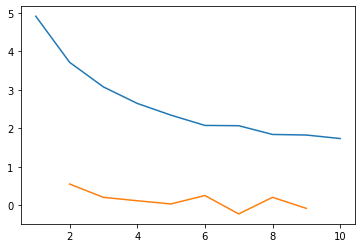

```
По методу локтя рекомендуется раздение на 2 кластеров
```

```python
# Метод локтя

end = linked[-10:, 2]
end_ = end[::-1]
idxs = np.arange(1, len(end) + 1)
plt.plot(idxs, end_)

acc = np.diff(end, 2)
acc_ = acc[::-1]
result = acc_.argmax() + 2
plt.plot(idxs[:-2] + 1, acc_)
plt.show()

print("По методу локтя рекомендуется раздение на", result, "кластеров" )
```

Также по графику видно что разделения на 6 и на 8 также хорошо подходят

По моему мнению, 2 - слишком маленькое кол-во, так что я возьму среднее значение - 6

```python
clusters=fcluster(linked, 6, criterion='maxclust')
[sum(clusters==x) for x in range(1,7)]
silhouette_score(data_normalized, clusters)
print("Оценка силуэта для кластеризации на 6 -", silhouette_score(data_normalized, clusters))
```

```
Оценка силуэта для кластеризации на 6 - 0.1305455059837325
```

Итог:

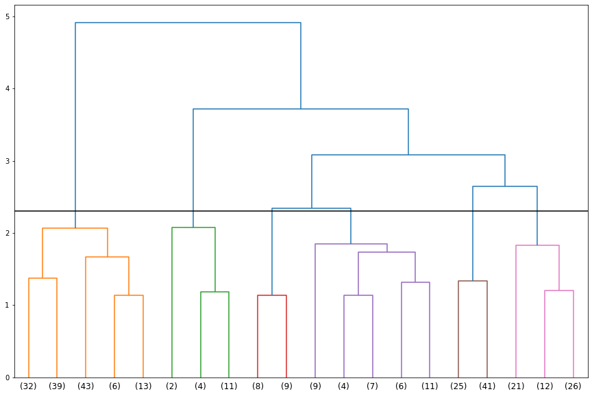

```python
ward_method = linkage(data_normalized, method='ward')
plt.figure(figsize=(15, 10))
dendrogram(ward_method, color_threshold=2.3,truncate_mode="lastp",p=20)
plt.axhline(y=2.3, c='k')
plt.show()
labels_hi = fcluster(ward_method, t=6, criterion='maxclust')
```

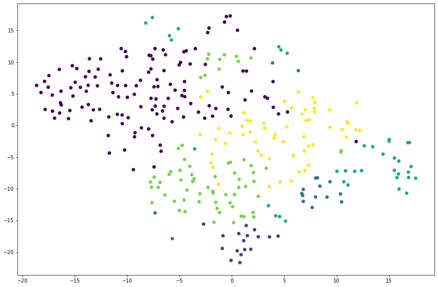

```python
tsne = TSNE(random_state=17)
tsne_rep = tsne.fit_transform(data_normalized)

plt.figure(figsize =(15, 10))
plt.scatter(tsne_rep[:, 0],
            tsne_rep[:, 1],
            c = labels_hi)
plt.show()
```

```python
silhouette_score(data_normalized, labels_hi)
```

```
0.1305455059837325
```

# Задание 3

```python
from sklearn.cluster import DBSCAN
```

```python
def my_score(arr):
    res = 0
    i = 0
    for x in arr:
        res -= ((-1) ** i) * x
        i += 1
    return abs(res)

array = np.arange(0.01,0.5,0.02)
results = [0,0,0,0,[]]
my_results = [0,0,0,9999,[]]
print("Общие результаты: ")
for eps in array:
    dbscan = DBSCAN(eps=eps, min_samples=2)
    labels_db = dbscan.fit_predict(data_normalized)
    cluster_sum = [sum(labels_db==x) for x in np.unique(labels_db)]
    if (3 < len(cluster_sum) < 10 ):
        score = silhouette_score(data_normalized, labels_db)
        myscore = my_score(cluster_sum)

        if score > results[2]:
            results = [eps,len(cluster_sum), score, myscore, cluster_sum]

        if myscore < my_results[3]:
            my_results = [eps,len(cluster_sum), score, myscore, cluster_sum]

        print('Eps - ',round(eps,3),
              ' |  clusters num - ', len(cluster_sum),
              ' |  score -',round(score,5),
              ' |  myscore -', myscore)

print('\nЛучший результат:')
print('Eps - ',round(results[0],3), '\nclustersnum - ', results[1], '\nscore -',results[2], '\nmy score -',results[3])
print(*results[4])

print('\nЛучший по моей схеме сравнения:')
print('Eps - ',round(my_results[0],3), '\nclustersnum - ', my_results[1], '\nscore -',my_results[2], '\nmy score -',my_results[3])
print(*my_results[4])
```

```
Общие результаты:
Eps -  0.11  |  clusters num -  8  |  score - -0.35356  |  myscore - 313
Eps -  0.23  |  clusters num -  7  |  score - 0.00634  |  myscore - 111
Eps -  0.25  |  clusters num -  7  |  score - 0.03866  |  myscore - 155
Eps -  0.27  |  clusters num -  8  |  score - 0.11417  |  myscore - 193
Eps -  0.29  |  clusters num -  9  |  score - 0.09657  |  myscore - 205
Eps -  0.31  |  clusters num -  8  |  score - 0.10177  |  myscore - 233
Eps -  0.33  |  clusters num -  8  |  score - 0.09957  |  myscore - 251
Eps -  0.35  |  clusters num -  4  |  score - 0.25664  |  myscore - 273
Eps -  0.37  |  clusters num -  4  |  score - 0.25897  |  myscore - 281

Лучший результат:
Eps -  0.37
clustersnum -  4
score - 0.25896729899604276
my score - 281
22 303 2 2

Лучший по моей схеме сравнения:
Eps -  0.23
clustersnum -  7
score - 0.006343348729277477
my score - 111
100 214 2 2 5 4 2
```

Видно, что данные малопригодны для кластеризации по плотности

Из всех eps нам по образу силуэта наиболее подходит 0.37, однако в нем слишком велики различия между кластерами

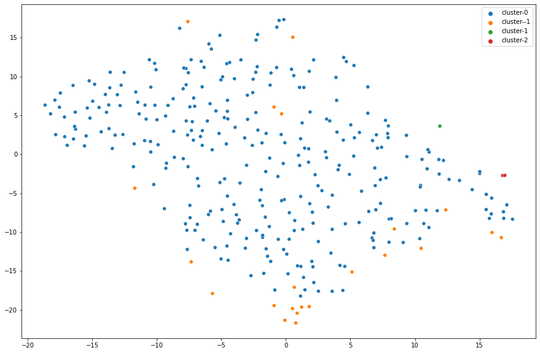

```python
dbscan = DBSCAN(eps=0.37, min_samples=2)
labels_db = dbscan.fit_predict(data_normalized)

fig = plt.figure(figsize=(15, 10))
fig.subplots_adjust(hspace=.5, wspace=.2)
sns.scatterplot(tsne_rep[:,0],
                tsne_rep[:,1],
                hue=["cluster-{}".format(h) for h in labels_db])
plt.show()
```

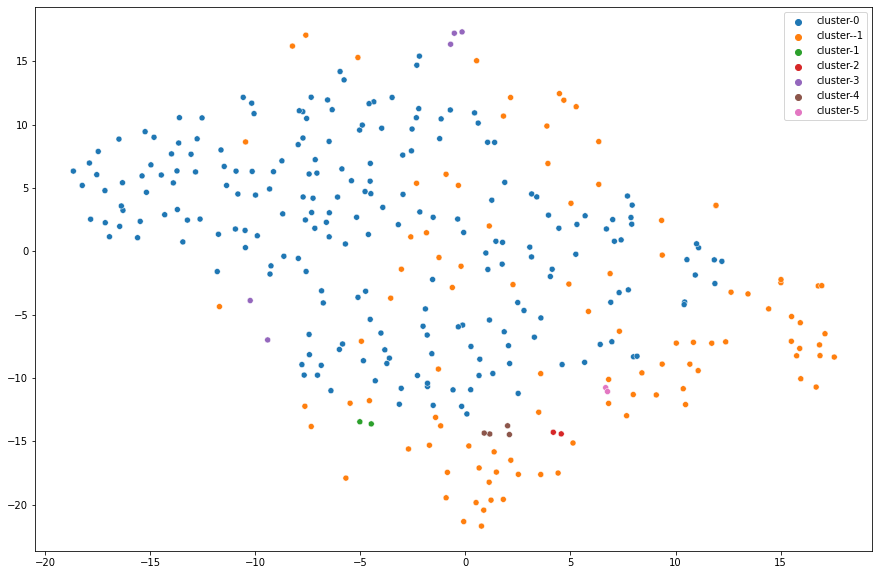

```python
dbscan = DBSCAN(eps=0.23, min_samples=2)
labels_db = dbscan.fit_predict(data_normalized)

fig = plt.figure(figsize=(15, 10))
fig.subplots_adjust(hspace=.5, wspace=.2)
sns.scatterplot(tsne_rep[:,0],
                tsne_rep[:,1],
                hue=["cluster-{}".format(h) for h in labels_db])
plt.show()
```

# Задание 4

```python
from sklearn.cluster import KMeans
```

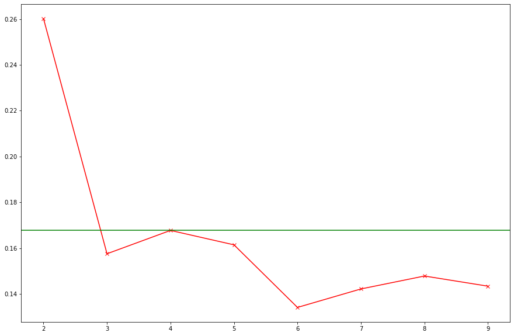

```python
plt.figure(figsize=(15, 10))
scores = []
for i in range(2, 10):
    kmeans = KMeans(n_clusters=i,
                    init = 'random',
                    n_init = 500,)
    kmeans.fit(data_normalized)
    labels_km = kmeans.predict(data_normalized)
    scores.append(silhouette_score(data_normalized, labels_km))

plt.plot(range(2, 10), scores, 'x-r')
plt.axhline(y=scores[2], color='g', linestyle='-')
plt.show()
```

```python
kmeans = KMeans(n_clusters=4,
                init = 'random',
                n_init = 500,)
kmeans.fit(data_normalized)
labels_km = kmeans.predict(data_normalized)
[sum(labels_km==x) for x in range(4)]
```

```
[96, 23, 54, 156]
```

```python
silhouette_score(data_normalized, labels_km)
```

```
0.16237972168144
```

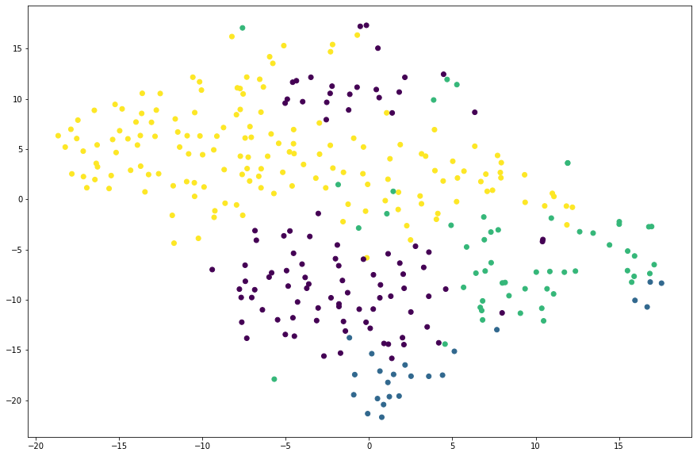

```python
plt.figure(figsize =(15, 10))
plt.scatter(tsne_rep[:, 0],
            tsne_rep[:, 1],
            c = labels_km)
plt.show()
```

# Задание 6

```
Hierarchical:  0.1305455059837325
```

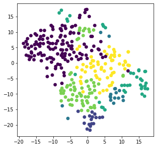

```python
print("Hierarchical: ",silhouette_score(data_normalized, labels_hi))
plt.figure(figsize =(5, 5))
plt.scatter(tsne_rep[:, 0],
            tsne_rep[:, 1],
            c = labels_hi)
plt.show()
```

```
DBSCAN:  0.006343348729277477
```

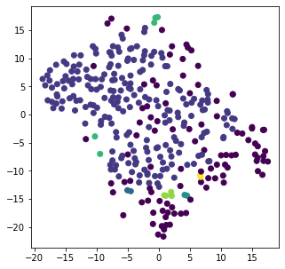

```python
print("DBSCAN: ",       silhouette_score(data_normalized, labels_db))
plt.figure(figsize =(5, 5))
plt.scatter(tsne_rep[:, 0],
            tsne_rep[:, 1],
            c = labels_db)
plt.show()
```

```
Kmeans : 0.16237972168144
```

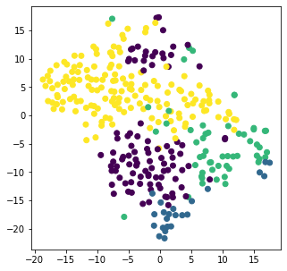

```python
print("Kmeans :", silhouette_score(data_normalized, labels_km))
plt.figure(figsize =(5, 5))
plt.scatter(tsne_rep[:, 0],
            tsne_rep[:, 1],
            c = labels_km)
plt.show()
```

Ясно видно, что наиболее подходящая кластеризация была проведена с помощью алгоритма Kmeans

DBSCAN показал наихудший результат среди своих оппонентов

Также легко заметить что у Kmeans и Hierarchecal метрики и результаты схожи друг с другом

# Задание 7

Для анализа я выбрал кластеры отобранные Kmeans

```python
clusters = labels_km
```

```python
data[clusters == 0]
```

|  | Climate | HousingCost | HlthCare | Crime | Transp | Educ | Arts | Recreat | Econ | Pop |
| --- | --- | --- | --- | --- | --- | --- | --- | --- | --- | --- |
| 1 | 575 | 8138 | 1656 | 886 | 4883 | 2438 | 5564 | 2632 | 4350 | 660328 |
| 3 | 476 | 7908 | 1431 | 610 | 6883 | 3399 | 4655 | 1617 | 5864 | 835880 |
| 4 | 659 | 8393 | 1853 | 1483 | 6558 | 3026 | 4496 | 2612 | 5727 | 419700 |
| 7 | 537 | 6487 | 965 | 706 | 4975 | 2945 | 1487 | 1280 | 5795 | 268229 |
| 9 | 609 | 6546 | 669 | 1073 | 4902 | 2852 | 1235 | 1109 | 6241 | 173699 |
| ... | ... | ... | ... | ... | ... | ... | ... | ... | ... | ... |
| 299 | 518 | 7767 | 1738 | 998 | 5323 | 2852 | 4389 | 1952 | 4534 | 616864 |
| 300 | 501 | 7110 | 1148 | 999 | 5348 | 2795 | 1632 | 1141 | 5464 | 154916 |
| 301 | 636 | 10616 | 1372 | 1181 | 4786 | 3311 | 5029 | 1646 | 5772 | 307863 |
| 306 | 548 | 6744 | 391 | 400 | 4592 | 2970 | 858 | 1750 | 5226 | 320180 |
| 322 | 597 | 7927 | 1445 | 1115 | 4532 | 3112 | 4545 | 1923 | 6174 | 523221 |

96 rows × 10 columns

Средняя стоимость проживания  
Выше среднего развита медицина  
Средний (возможно, немного выше среднего) уровень преступности  
Высокая популяция населения  
Высоко развиты транспортнные системы  
Выше среднего среди оппонентов развиваются искусство и культура  
Ниже среднего экономика

Предпологаю что в этом кластере расположились средние и большие города, не попадающие по критериям во 2-й кластер  
На карте они будут отмечены синим

```python
data[clusters == 1]
```

|  | Climate | HousingCost | HlthCare | Crime | Transp | Educ | Arts | Recreat | Econ | Pop |
| --- | --- | --- | --- | --- | --- | --- | --- | --- | --- | --- |
| 19 | 696 | 8316 | 3195 | 1308 | 8409 | 3057 | 7559 | 1362 | 6315 | 2138231 |
| 25 | 567 | 9148 | 3562 | 1730 | 7405 | 3471 | 9788 | 2925 | 5503 | 2199531 |
| 42 | 623 | 11609 | 5301 | 1215 | 6801 | 3479 | 21042 | 3066 | 6363 | 2805911 |
| 64 | 514 | 10913 | 5766 | 1034 | 7742 | 3486 | 24846 | 2856 | 5205 | 6060387 |
| 68 | 579 | 9168 | 3167 | 1138 | 7333 | 2972 | 12679 | 3300 | 4879 | 1898825 |
| 76 | 544 | 9318 | 2825 | 1529 | 6213 | 3269 | 10438 | 2310 | 7710 | 1957378 |
| 83 | 521 | 10789 | 2533 | 1365 | 8145 | 3145 | 8477 | 2324 | 7164 | 1428836 |
| 85 | 536 | 8525 | 4142 | 1587 | 4808 | 3064 | 10389 | 2483 | 3904 | 4488072 |
| 130 | 516 | 11652 | 2521 | 1279 | 7120 | 3628 | 3616 | 1790 | 6307 | 715923 |
| 134 | 424 | 9760 | 2467 | 1499 | 4626 | 3271 | 11073 | 1825 | 7464 | 2735766 |
| 178 | 885 | 13868 | 5153 | 1960 | 4345 | 3195 | 23567 | 3948 | 5316 | 7477503 |
| 191 | 634 | 10267 | 2314 | 2459 | 5202 | 2879 | 4837 | 4300 | 5840 | 1625781 |
| 212 | 638 | 13358 | 7850 | 2498 | 8625 | 2984 | 56745 | 3579 | 5338 | 8274961 |
| 213 | 601 | 14220 | 4106 | 1461 | 3514 | 3362 | 14224 | 1818 | 5690 | 1878959 |
| 217 | 910 | 13135 | 2362 | 1533 | 6430 | 2646 | 6162 | 2394 | 5457 | 1761759 |
| 233 | 630 | 8310 | 5158 | 1059 | 5903 | 3781 | 17270 | 1979 | 5638 | 4716818 |
| 236 | 586 | 8099 | 3413 | 687 | 5616 | 3544 | 11069 | 2145 | 5261 | 2218870 |
| 239 | 768 | 9912 | 1590 | 1504 | 5947 | 3343 | 5160 | 2532 | 4535 | 1105699 |
| 261 | 537 | 7605 | 2850 | 1306 | 7119 | 3530 | 8896 | 2243 | 5800 | 1808621 |
| 268 | 903 | 14465 | 2416 | 1099 | 5489 | 2794 | 8818 | 3347 | 5489 | 1861846 |
| 269 | 910 | 17158 | 3726 | 1619 | 8299 | 3371 | 14226 | 4600 | 6063 | 1488871 |
| 277 | 808 | 10183 | 2715 | 1170 | 6634 | 2710 | 9577 | 4800 | 5901 | 1607469 |
| 313 | 631 | 13724 | 4361 | 1317 | 8236 | 3635 | 21701 | 1578 | 6072 | 3250822 |

Наивысшая стоимость проживания  
Наивысший уровень преступности  
Наилучшие транспортные системы  
Экономика выше среднего  
Среди других наиболшие деньги идут на развитие искусства и культуры  
Наивысшая популяция населения  
Низкое кол-во городов в самом кластере

Предполагаю что в этом кластере расположились крупные города и мегаполисы  
На карте они будут отмечены зеленым

```python
data[clusters == 2]
```

|  | Climate | HousingCost | HlthCare | Crime | Transp | Educ | Arts | Recreat | Econ | Pop |
| --- | --- | --- | --- | --- | --- | --- | --- | --- | --- | --- |
| 10 | 885 | 16047 | 2025 | 983 | 3954 | 2843 | 5632 | 3156 | 6220 | 1932709 |
| 11 | 195 | 12175 | 601 | 1223 | 5091 | 2414 | 2346 | 3000 | 7668 | 174431 |
| 20 | 615 | 11074 | 637 | 1878 | 3556 | 2929 | 621 | 2711 | 8107 | 276385 |
| 31 | 772 | 8329 | 240 | 825 | 3776 | 2778 | 1302 | 3200 | 4247 | 106701 |
| 33 | 559 | 14607 | 2661 | 857 | 3511 | 3653 | 9304 | 1918 | 6016 | 1292970 |
| ... | ... | ... | ... | ... | ... | ... | ... | ... | ... | ... |
| 303 | 530 | 7498 | 1581 | 1080 | 3758 | 2628 | 4248 | 2024 | 7115 | 657173 |
| 307 | 821 | 10503 | 1079 | 964 | 4153 | 2498 | 2962 | 1559 | 5819 | 334402 |
| 311 | 543 | 7778 | 210 | 1132 | 3094 | 2128 | 511 | 2800 | 5563 | 245738 |
| 317 | 509 | 10512 | 375 | 1783 | 5201 | 3224 | 2888 | 3772 | 7992 | 576863 |
| 323 | 564 | 6858 | 1099 | 1423 | 2904 | 2876 | 1077 | 2668 | 5390 | 103471 |

54 rows × 10 columns

Предполагаю что в этом кластере расположились города-курорты и исторически ценные для страны города  
На карте они будут отмечены синим красным

```python
data[clusters == 3]
```

|  | Climate | HousingCost | HlthCare | Crime | Transp | Educ | Arts | Recreat | Econ | Pop |
| --- | --- | --- | --- | --- | --- | --- | --- | --- | --- | --- |
| 0 | 521 | 6200 | 237 | 923 | 4031 | 2757 | 996 | 1405 | 7633 | 110932 |
| 2 | 468 | 7339 | 618 | 970 | 2531 | 2560 | 237 | 859 | 5250 | 112402 |
| 5 | 520 | 5819 | 640 | 727 | 2444 | 2972 | 334 | 1018 | 5254 | 135282 |
| 6 | 559 | 8288 | 621 | 514 | 2881 | 3144 | 2333 | 1117 | 5097 | 635481 |
| 8 | 561 | 6191 | 432 | 399 | 4246 | 2778 | 256 | 1210 | 4230 | 136621 |
| ... | ... | ... | ... | ... | ... | ... | ... | ... | ... | ... |
| 324 | 562 | 8715 | 1805 | 680 | 3643 | 3299 | 1784 | 910 | 5040 | 402918 |
| 325 | 535 | 6440 | 317 | 1106 | 3731 | 2491 | 996 | 2140 | 4986 | 172508 |
| 326 | 540 | 8371 | 713 | 440 | 2267 | 2903 | 1022 | 842 | 4946 | 381255 |
| 327 | 570 | 7021 | 1097 | 938 | 3374 | 2920 | 2797 | 1327 | 3894 | 531350 |
| 328 | 608 | 7875 | 212 | 1179 | 2768 | 2387 | 122 | 918 | 4694 | 101979 |

156 rows × 10 columns

В среднем, медицина хуже среднего  
Низкий уровень преступности  
Слабо развиты транспортные системы  
Развитие искусства и культуры наихудшее повсеместно  
В среднем, худшая экономика

Предполагаю что в этом кластере расположились малые города, пригороды и деревни  
На карте они будут отмечены серым

# Задание 8

```python
import folium

data = pd.read_csv('Data.txt', sep=' ')
data['label'] = labels_km

colors = {0: "blue", 1: "green", 2: "red", 3: "gray"}

usa_map = folium.Map(location=[39.091431, -96.655998], zoom_start=4)

for i, town in data.iterrows():
    folium.Marker(
        location = (town.Lat, town.Long),
        icon = folium.Icon(color=colors[town['label']]),).add_to(usa_map)

usa_map
```

Make this Notebook Trusted to load map: File -> Trust Notebook

[interactive chart not shown]

Серые - малые города, пригороды и деревни. Географически составить о них вывод сложно, так как они распололжены по всей стране  
Можно лишь заметить что с каждым большим (зеленым) городом находится от 2 серых

Зеленые - мегаполисы (Сан-Франциско, Лос-Анжелес, Вашингтон). Зачастую столицы штатов

Синие - Следующие по величине после зеленых города. Также иногда являются столицами, но гораздо реже чем зеленые

Красные - города-курорты, например Лас-Вегас. Расположены как правило у побережья,  
что доказывает их принадлежность к туристичскому бизнесу